# AOOI3_Aula06_DiagramasAtividades

Instituto Federal de São Paulo (IFSP)  
[Campus Bragança Paulista/SP](https://bra.ifsp.edu.br)  
**Análise e Desenvolvimento de Sistemas (ADS)**  
**3o. módulo**  
**Profa. Ana Paula Müller Giancoli**  
paulagiancoli@ifsp.edu.br

## AULA 06 - DIAGRAMA DE ATIVIDADES

### Agenda

- Diagramas de Atividades
  - Para que serve?
  - Como desenhá-lo?
  - Definição
  - Notação
  - Modelagem de um Fluxo de Atividade
- Perguntas

### 1. Para que serve ?

- Permite modelar o comportamento de um sistema, denotando os caminhos lógicos que um processo poderá seguir.

### 2. Como desenhá-lo?

- É necessário o entendimento de um processo para que em uma segunda etapa escrevê-lo ou gerar o código adequado para seu comportamento.
- Ao compararmos com a Lógica de Programação: semelhante aos fluxogramas, porém cada qual com suas notações, simbologias.

### 3. Definição

- Modela as etapas sequenciais em um processo computacional, por meio da descrição detalhada dos passos necessários para a realização de cada caso de uso do sistema.
- Compõem a visão dinâmica da UML, modelando os aspectos dinâmicos de um sistema.

**Figura 1: Representação de um Diagrama de Atividades por meio de raias**

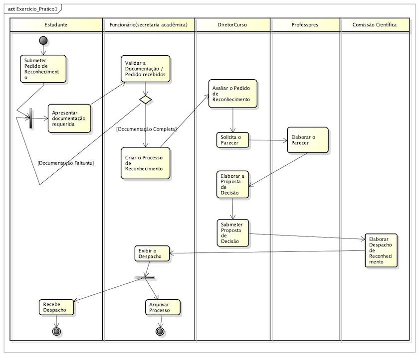

Fonte: Autoria própria

### 4.2. Fluxo

- **Fluxo** representa as passagens de uma atividade para outra.
- A seta indica a direção do fluxo.

### 4.3. Decisão

- **Decisão** é representada pelo símbolo do losango.
- O fato de ter 4 cantos não significa que podemos ter somente 4 saídas.
- Podemos ter diversas saídas para o símbolo de decisão.

**Figura 4: Representação de uma Decisão**

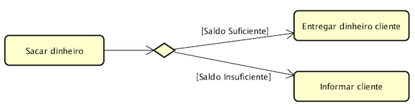

Fonte: Autoria própria

**Figura 5: Representação de uma Decisão**

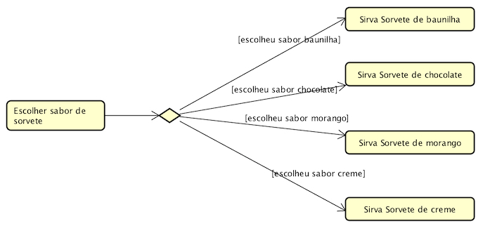

Fonte: Autoria própria

### 4.4. Join (União)

- **Join** é representado pelo símbolo abaixo.
- Significa que mais de uma atividade chegou em um mesmo ponto e criou-se uma nova atividade, a partir da união das atividades.

Figura 6: Representação do Join

**Figura 6a: Representação do Símbolo Join**

**Figura 6b: Representação do Símbolo Join**

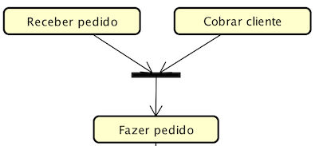

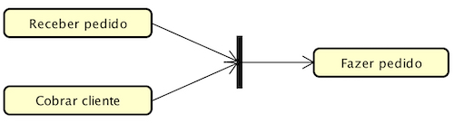

Fonte: Autoria própria

Fonte: Autoria própria

### 4.5. Fork (Divisão)

- **Fork** é representado pelo símbolo abaixo.
- Significa que uma atividade chegou neste ponto e foi subdividida em mais de uma atividade.

Figura 7: Representação do Fork

**Figura 7a: Representação do Símbolo Fork**

**Figura 7b: Representação do Símbolo Fork**

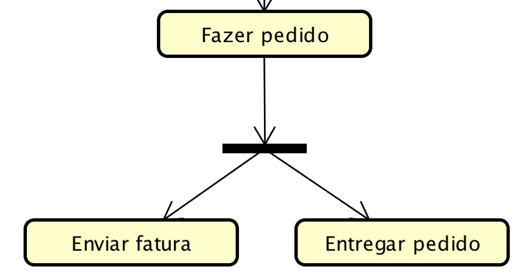

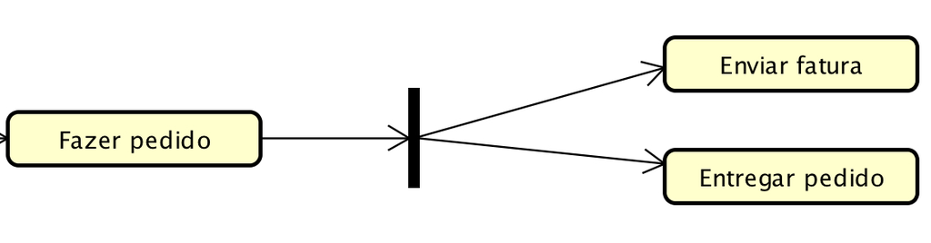

Fonte: Autoria própria

Fonte: Autoria própria

### 4.9. Conector

- Conector é utilizado para conectar parte do diagrama à outra parte, sem gerar linhas cruzadas, ou atividades repetidas.

### 4.10. Merge

- Merge representado pelo mesmo símbolo de decisão, um losango vazio, onde sua semântica foi alterada para também significar o merge.
- Neste símbolo, vários fluxos estão convergindo a um ponto e existe apenas uma saída, o que é diferente do fork, onde vários fluxos saem concorrentemente.

**Figura 12: Representação do Símbolo Merge**

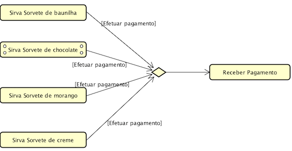

Fonte: Autoria própria

### 4.11. Condição

- Condição poderá ser expressada por meio do uso de colchetes e em itálico, sobre um fluxo.

### 4.12. Swinlanes (Raias)

- Swinlanes este símbolo reproduz as raias de uma piscina.
- Indica a passagem do fluxo de uma atividade entre um ator e outro.
- Pode ser representado na vertical ou também, na Horizontal.
- É um recurso útil na modelagem de fluxos de trabalho de processos de negócio, para particionar em grupos os estados de atividades de um diagrama de atividades.
- Na UML, cada grupo é chamado de uma raia de natação, pois, visualmente, os grupos ficam separados de seus vizinhos por uma linha cheia vertical.
- A raia de natação especifica um local de atividades.
- Cada raia de natação tem um nome único em seu diagrama

**Figura 14: Representação do Símbolo das Raias**

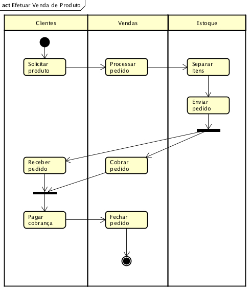

Fonte: Autoria própria

### 4.13. Rake (Rodo)

- Rake é uma espécie de tridente, voltado pra baixo, dentro de uma determinada atividade.
- Indica que aquela atividade tem subatividades ou as está invocando.
- Essas podem estar descritas em outro diagrama ou em outro ponto dentro do mesmo diagrama.

### 4.14. Nota

- Nota pode conter qualquer comentário desejável.
- É interessante comentarmos: merge, rake, swinlanes e, se necessário, as condições.
- O diagrama poderá conter uma única nota, com itens numerados sequencialmente, evitando poluir o visual.
- Os números podem aparecer em pequenos círculos indicando que existem comentários a respeito daquele item.
- Não é uma notação oficial da UML, mas facilita a identificação.

### 4.15. Região de Atividades Interrompidas

- A UML 2.0 trouxe este conceito.
- Exemplo: Suponha que um produto em um carrinho de compras, possa ser cancelado a qualquer tempo, exceto no momento em que a compra foi finalizada e o processo de pagamento terminado.

**Figura 17: Representação da Região de Atividade Interrompidas**

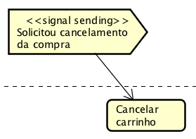

Fonte: Autoria própria

- A qualquer momento, dentro da região de interrupção, a atividade Cancelar Carrinho pode ser invocada.
- Adicionalmente, foi adicionado um símbolo de uma atividade abstrata, neste caso, representado por um evento “Solicitou Cancelamento da Compra”.

**Figura 18: Representação da Região de Atividade Interrompidas**

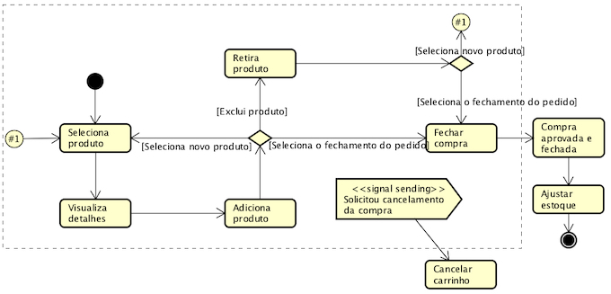

Fonte: Autoria própria

### 4.16. Sinais de Aceitação

- São eventos que podem ser representados sendo enviados e recebidos e provocam uma transição quando recebidos, assim também, como o símbolo de atividades periódicas.

**Figura 19: Representação da Sinais de Aceitação**

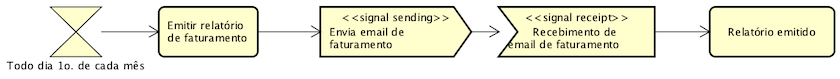

Fonte: Autoria própria

### 4.17. Atividades parametrizadas

- Significa que uma atividade pode receber e enviar um parâmetro.
- Isto é representado por um pequeno retângulo colocado à atividade, chamado de PIN.
- Com finalidade de que as ações recebam e geram resultados.

**Figura 20: Representação de Atividades Parametrizadas**

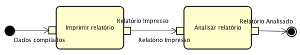

Fonte: Autoria própria

### 4.18. Modelagem De um Fluxo de Atividade

- 1.Estabeleça um foco para o fluxo de trabalho.
- 2.Para sistemas não-triviais, é impossível mostrar todos os fluxos de trabalho interessantes em um mesmo diagrama.
- 3.Selecione os objetos de negócio que têm responsabilidades de alto nível para partes do fluxo de trabalho geral.
- 4.Esses objetos poderão ser coisas reais definidas a partir do vocabulário do sistema ou poderão ser mais abstratos.
- 5.Em qualquer caso, crie uma raia de natação para cada objeto de negócio importante.
- 6.Identifique as pré-condições do estado inicial do fluxo de trabalho e as pós- condições do estado final do fluxo de trabalho.
- 7.Isso é importante para ajudar a modelagem das fronteiras do fluxo de trabalho.
- 8.Começando no estado inicial do fluxo de trabalho, especifique as atividades e ações realizadas ao longo do tempo e represente-as no diagrama de atividade como estados de atividades ou estados de ação.

### Referências

- Esta aula foi elaborada a partir do conteúdo disponibilizado em cada um dos links indicados no próprio texto.
- GUEDES, G. T. A. UML 2 - **UMA ABORDAGEM PRÁTICA**. [S.L.]: NOVATEC, 2011.
- MEDEIROS, Ernani - **Desenvolvendo Software com UML 2.0 Definitivo** - Editora Pearson Makron Books.
- BOOCH, Grady; RUMBAUGH, James; JACOBSON, Ivar - **UML Guia do Usuário** - 2a. Edição - Editora Campus (Elsevier).

### Perguntas

- Esclareça suas eventuais dúvidas durante as aulas.
- Ou pelo *E-mail*: paulagiancoli@ifsp.edu.br.
- Ou acesse [Github Ana Giancoli](https://anagiancoli.github.io) e solicite atendimento para o componente curricular.
- Ou pelo *Fórum* do componente curricular.

*ADS - AOO - 3o. módulo*.  
Modelo e formato elaborado por profa. Ana Paula Müller Giancoli - BSD 2-Clause License. - Setembro.2020.